# Visualization

## Setup

The first chunk in an R Notebook is usually titled “setup,” and by convention includes the R packages you want to load. Remember, in order to use an R package you have to run some `library()` code every session. Execute these lines of code to load the packages.

```r
library(ggplot2)
library(fivethirtyeight)
```

## Bechdel test data

We’re going to start by playing with data collected by the website FiveThirtyEight on movies and [the Bechdel test](https://en.wikipedia.org/wiki/Bechdel_test).

To begin, let’s just preview our data. There are a couple ways to do that. One is just to type the name of the data and execute it like a piece of code.

```r
bechdel
```

| year | imdb | title | test | clean_test | binary | budget | domgross | intgross | code | budget_2013 | domgross_2013 | intgross_2013 | period_code | decade_code |
| --- | --- | --- | --- | --- | --- | --- | --- | --- | --- | --- | --- | --- | --- | --- |
| 2013 | tt1711425 | 21 & Over | notalk | notalk | FAIL | 13000000 | 25682380 | 42195766 | 2013FAIL | 13000000 | 25682380 | 42195766 | 1 | 1 |
| 2012 | tt1343727 | Dredd 3D | ok-disagree | ok | PASS | 45000000 | 13414714 | 40868994 | 2012PASS | 45658735 | 13611086 | 41467257 | 1 | 1 |
| 2013 | tt2024544 | 12 Years a Slave | notalk-disagree | notalk | FAIL | 20000000 | 53107035 | 158607035 | 2013FAIL | 20000000 | 53107035 | 158607035 | 1 | 1 |
| 2013 | tt1272878 | 2 Guns | notalk | notalk | FAIL | 61000000 | 75612460 | 132493015 | 2013FAIL | 61000000 | 75612460 | 132493015 | 1 | 1 |
| 2013 | tt0453562 | 42 | men | men | FAIL | 40000000 | 95020213 | 95020213 | 2013FAIL | 40000000 | 95020213 | 95020213 | 1 | 1 |
| 2013 | tt1335975 | 47 Ronin | men | men | FAIL | 225000000 | 38362475 | 145803842 | 2013FAIL | 225000000 | 38362475 | 145803842 | 1 | 1 |
| 2013 | tt1606378 | A Good Day to Die Hard | notalk | notalk | FAIL | 92000000 | 67349198 | 304249198 | 2013FAIL | 92000000 | 67349198 | 304249198 | 1 | 1 |
| 2013 | tt2194499 | About Time | ok-disagree | ok | PASS | 12000000 | 15323921 | 87324746 | 2013PASS | 12000000 | 15323921 | 87324746 | 1 | 1 |
| 2013 | tt1814621 | Admission | ok | ok | PASS | 13000000 | 18007317 | 18007317 | 2013PASS | 13000000 | 18007317 | 18007317 | 1 | 1 |
| 2013 | tt1815862 | After Earth | notalk | notalk | FAIL | 130000000 | 60522097 | 244373198 | 2013FAIL | 130000000 | 60522097 | 244373198 | 1 | 1 |

[output cut: 1784 more lines]

Notice that you can page through to see more of the dataset.

Sometimes, people prefer to see their data in a more spreadsheet-like format, and RStudio provides a way to do that. Go to the Console and type `View(bechdel)` to see the data preview.

(An aside– `View` is a special function. Since it makes something happen in the RStudio interface, it doesn’t work properly in R Notebooks. Most R functions have names that start with lowercase letters, so the uppercase “V” is there to remind you of its special status.)

## Your Turn 2

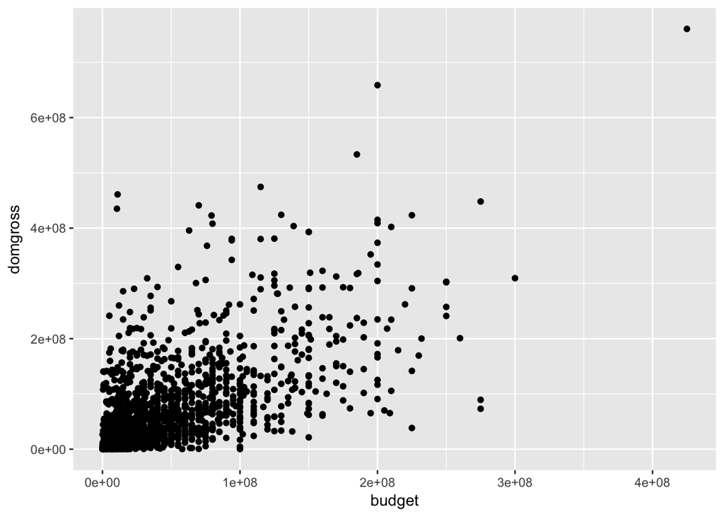

```r
ggplot(data = bechdel) +
  geom_point(mapping = aes(x = budget, y = domgross))
```

## Set vs map

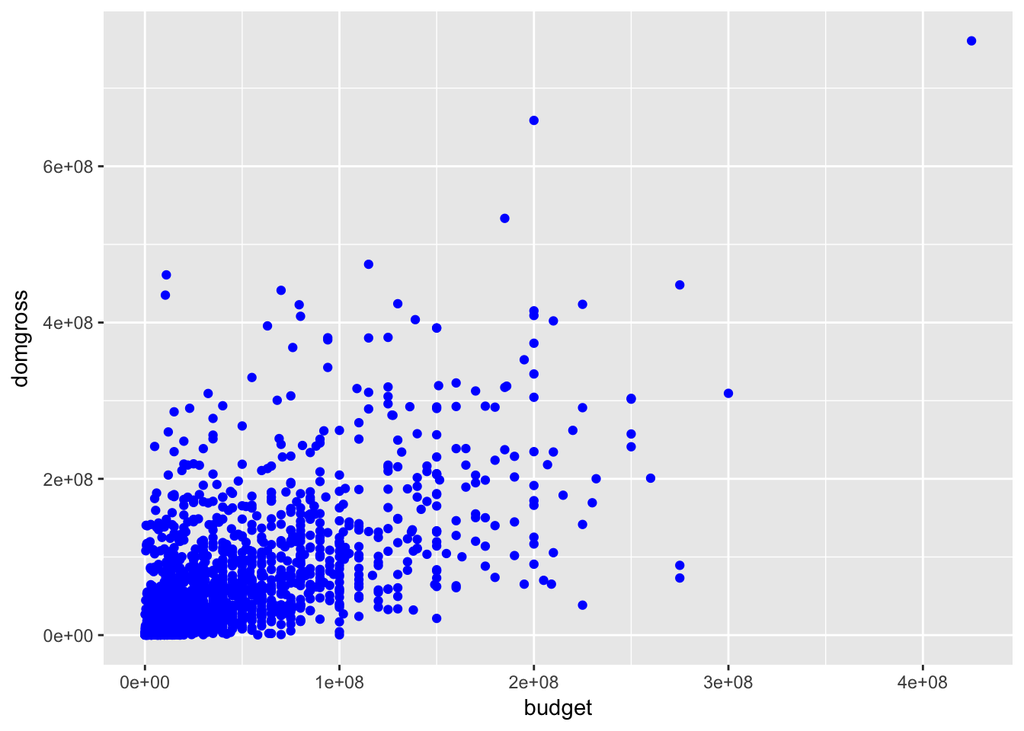

```r
ggplot(bechdel) +
    geom_point(mapping = aes(x = budget, y = domgross), color="blue")
```